# CEE6501 — Lecture 11.1

## Introduction to Nonlinearity

## Learning Objectives

By the end of this lecture, you will be able to:

- explain the difference between **linear** and **nonlinear** structural analysis
- distinguish between **material** and **geometric** nonlinearity
- describe the main **levels of analysis** used in structural engineering
- explain the course focus on **geometric nonlinearity** for **axial-member structures**
- explain why a simple plane truss can have a **nonlinear load-displacement response** even with linearly elastic material
- describe the ideas of **critical point** and **snap-through instability**

## Agenda

- Part 1 — What Is Nonlinearity?
- Part 2 — Types of Nonlinearity
- Part 3 — Levels of Analysis
- Part 4 — Scope for This Course
- Part 5 — Basic Concept of Geometrically Nonlinear Analysis
- Part 6 — Example of Linear vs. Geometrically Nonlinear Analysis

## Part 1 — What Is Nonlinearity?

> We begin by stepping beyond the assumptions of ordinary linear structural analysis.

### Review: What Linear Analysis Assumes

In the usual **linear** structural analysis, we rely on two key assumptions:

- **Geometric linearity**: deformations are small enough that equilibrium can be written on the **undeformed geometry**
- **Material linearity**: stress is proportional to strain, so the material remains **linearly elastic**

In its simplest form, linear structural analysis gives a relation such as

$$ \mathbf{K}\mathbf{u} = \mathbf{f} $$

where:

- $\mathbf{K}$ is constant
- response is proportional to load
- superposition holds

This is often adequate for many structures under ordinary **service-load** conditions.

### A Simple Mathematical View

In a **linear** structural problem, the applied load and the response are proportional.

For a single degree of freedom spring:

$$ f = ku $$

where:

- $f$ = applied force
- $u$ = displacement
- $k$ = stiffness

If $k$ is constant, then doubling the load doubles the displacement:

$$ 2f = k \times 2u $$

So the force-displacement curve is a **straight line**.

In a **nonlinear** problem, that proportional relationship no longer holds.

The response may instead look like.

$$ f = f(u) $$

which means the force, $f$, is some nonlinear function of displacement, $u$.

For example, the slope of a member may change as the structure deforms, so the stiffness is no longer constant:

$$ k_{\text{tangent}} = \frac{df}{du} $$

### Why Nonlinear Analysis Is Needed

As loads increase, or as deformations become significant, the assumptions of linear analysis begin to break down.

A structure may become nonlinear because:

- its **geometry changes enough** during deformation to affect equilibrium and internal force
- its **material behavior changes**, for example through yielding, cracking, or inelastic response

Then the structural response is no longer a straight-line relation between load and displacement.

**Main idea:** in a nonlinear problem, the structure you are solving for also changes while you solve it.

### Nonlinear Equilibrium in the Structural Context

At the structural level, we usually write the problem in terms of **equilibrium** between external and internal forces:

$$ \mathbf{r}(\mathbf{u}) = \mathbf{f}_{\mathrm{ext}} - \mathbf{f}_{\mathrm{int}}(\mathbf{u}) = \mathbf{0} $$

Here:

- $\mathbf{f}_{\mathrm{ext}}$ is the applied load vector
- $\mathbf{f}_{\mathrm{int}}(\mathbf{u})$ is the internal resisting force vector, written as a function of the current nodal position
- $\mathbf{r}(\mathbf{u})$ is the **residual**, or out-of-balance force vector, also written as a function of the current nodal position

So in a nonlinear analysis, the goal is to find the displacement state $\mathbf{u}$ for which the structure is in equilibrium.

This is harder than the linear case because:

- the internal force depends on the current displacement
- the stiffness may change as the structure deforms
- the solution usually must be found **iteratively**

### Why This Matters in Structural Engineering

Linear analysis is often very useful, but it has inherent limitations.

It may not capture:

- loss of stiffness caused by large deformations
- second-order effects such as **$P$-$\Delta$** and **$P$-$\delta$**
- instability phenomena such as buckling
- inelastic material behavior and strength degradation

So nonlinear analysis becomes important when the goal is not only to compute forces and displacements under service conditions, but also to understand:

- ultimate strength
- stability
- large-deformation behavior
- failure mechanisms

## Part 2 — Types of Nonlinearity

### Material Nonlinearity

One major source of structural nonlinearity is **material nonlinearity**.

The constitutive law is nonlinear, so the relationship between stress and strain is no longer a straight line.

For a linear elastic material, we write

$$ \sigma = E\varepsilon $$

where the slope $E$ is constant.

For a nonlinear material, the stress is some more general function of strain:

$$ \sigma = \sigma(\varepsilon) $$

So the material stiffness is no longer constant. Instead, the slope changes as the material deforms:

$$ E_{tangent} = \frac{d\sigma}{d\varepsilon} $$

### Examples of Material Nonlinearity

Material nonlinearity arises when the stress-strain law is not linear elastic.

Typical examples include:

- yielding of steel
- cracking of reinforced concrete
- creep or time-dependent deformation
- nonlinear interaction of axial force, bending, shear, and torsion

Conceptually:

- the material stiffness changes as loading proceeds
- unloading and reloading may follow different paths
- the load-displacement curve can become history-dependent

For a linear elastic material, the slope is constant. For a nonlinear material, the tangent stiffness changes along the response path.

### Geometric Nonlinearity

The second major source is **geometric nonlinearity**.

The deformation is large enough that the changing geometry affects equilibrium, compatibility, and internal force.

In a linear analysis, we treat the structure as if its geometry does not change significantly during loading, so the stiffness is taken as fixed.

In a geometrically nonlinear analysis, the current deformed shape affects the response, so the stiffness depends on the structure's current nodal positions:

$$ \mathbf{K} = \mathbf{K}(\mathbf{u}) $$

Equivalently, the internal resisting forces depend on the current nodal positions:

$$ \mathbf{f}_{\mathrm{int}} = \mathbf{f}_{\mathrm{int}}(\mathbf{u}) $$

### Examples of Geometric Nonlinearity

Geometric nonlinearity arises when deformations become large enough that the current geometry cannot be ignored.

Typical examples include:

- $P$-$\Delta$ effect: gravity load acting through a lateral story displacement
- $P$-$\delta$ effect: axial force interacting with member curvature
- cables, membranes, or very flexible trusses whose stiffness depends strongly on shape (need to be form-found)
- structures undergoing large displacement before reaching material failure

Conceptually:

- equilibrium must be written on the **deformed** configuration
- internal force depends on both displacement and applied load
- stiffness becomes configuration-dependent

### Combined Nonlinear Effects

In many realistic structural problems, the two types of nonlinearity occur together.

Examples include:

- a steel frame with both **yielding** and **$P$-$\Delta$ effects**
- reinforced concrete members with **cracking** and **large deflections**
- frames where connection deformation, panel-zone deformation, and stability effects all interact

A useful way to think about it is:

- **material nonlinearity** changes the constitutive law
- **geometric nonlinearity** changes the equilibrium problem

In a first introduction, it is common to isolate one source of nonlinearity at a time.

## Part 3 — Levels of Analysis

### Why We Talk About Levels of Analysis

It is rarely practical to model every source of nonlinearity in full detail.

So structural analysis is often organized into **levels of analysis**, where each level captures more of the true behavior than the one before it.

These levels differ in:

- what assumptions are retained
- what sources of nonlinearity are included
- what kinds of failure or instability they can detect
- the computational effort required

Each higher level is not just "more complicated" — it is answering a different question about the structure.

### First-Order Elastic Analysis

This is the standard **linear** analysis we have used so far.

**Assumptions**

- equilibrium written on the **undeformed** structure
- material remains **linearly elastic**
- stiffness remains constant

**What it misses**

- geometric nonlinear effects
- material nonlinear effects
- instability behavior

$$ \mathbf{K}\mathbf{u} = \mathbf{f} $$

[figure not shown]

### Second-Order Elastic Analysis

This level includes the effects of deformation on equilibrium while still assuming elastic material behavior.

So it can represent:

- finite displacement effects
- $P$-$\Delta$ effects
- $P$-$\delta$ effects
- some aspects of stability and load amplification

But it still does **not** represent yielding, cracking, or other material nonlinearity.

Symbolically, the problem begins to look like

$$ \mathbf{K}(\mathbf{u}) \mathbf{u} = \mathbf{f} $$

or, more carefully, as a sequence of updated equilibrium states.

Several possible modes of nonlinear elastic behavior are shown.

- **bifurcation** of the load path into an alternative branch
- gradual softening that culminates in an **elastic instability** at a limit point
- stiffness changes that may lead to either softening or stiffening behavior

[figure not shown]

### First-Order Inelastic and Second-Order Inelastic Analysis

More advanced levels of analysis include material nonlinearity, with or without geometric nonlinearity.

**First-order inelastic**

- includes material nonlinearity
- keeps equilibrium on the undeformed geometry
- can represent plastic response, but not geometric nonlinear instability effects

**Second-order inelastic**

- includes both **material** and **geometric** nonlinearity
- is the most general of these common levels
- can represent strength loss, stability limits, and strongly nonlinear response

Much more involved than what we need for our immediate goals.

[figure not shown]

## Summary of the Levels of Analysis

| Level of analysis | Geometric nonlinearity? | Material nonlinearity? | Typical use |
| --- | --- | --- | --- |
| First-order elastic | No | No | Basic service-load response |
| Second-order elastic | Yes | No | Large-displacement elastic response, stability effects |
| First-order inelastic | No | Yes | Inelastic material response without geometric effects |
| Second-order inelastic | Yes | Yes | Most general response including strength and stability |

## Part 4 — Scope for This Course

### What We Will Focus On

In CEE6501, we will **not** attempt a general treatment of all nonlinear structural analysis.

Instead, we will focus on:

- geometric nonlinearity
- axial elements only
- bar and joint frameworks (trusses, space frames, cable nets, etc.)
- initially in 2D plane trusses

So the goal is not a full nonlinear analysis of general frames or continuous surfaces.

The goal is to understand the **basic concepts of geometrically nonlinear analysis** for axial-member structures whose stiffness and equilibrium depend strongly on their deformed shape.

### Why This Narrower Scope Makes Sense

This narrower focus connects directly to **form finding**, which is fundamentally an inverse problem:

- instead of asking for the response of a known structure
- we ask what **structural form** results from a given set of inputs, constraints, and force patterns

That requires the structure to **change shape** until forces come into equilibrium, so it is naturally formulated as a **geometrically nonlinear** problem.

So before we can find shapes that are in equilibrium, we first need a basic understanding of **geometric nonlinearity**.

### Textbook Readings

McGuire provides the broader background for nonlinear analysis, especially in:

- **Chapter 8** — introduction to nonlinear behavior and analysis
- **Chapter 9** — geometric nonlinearity and elastic critical load analysis
- **Chapter 10** — material nonlinear analysis

From McGuire, we take the big-picture framework:

- what nonlinearity is
- the main types of nonlinearity
- the common levels of analysis

From here, we narrow the scope.

Following Kassimali (Chapter 10) more closely, we will study only the **basic concepts of geometrically nonlinear analysis** for **plane trusses**.

Our focus will be on:

- axial elements only
- large displacements
- equilibrium on the deformed geometry
- iterative solution and convergence

## Part 5 — Basic Concept of Geometrically Nonlinear Analysis

### The Example Structure

To illustrate the basic concept of **geometrically nonlinear analysis**, we consider a simple symmetric **two-member plane truss** made of a linearly elastic material.

The structure is loaded by a vertical load $P$ at the top joint, so the motion is described by a single degree of freedom:

$$ \delta = \text{vertical displacement of joint 2} $$

[figure not shown]

Because the structure is symmetric:

- both members have the same undeformed length $L$
- both members have the same area $A$
- both members have the same angle $\theta$ in the undeformed configuration
- both members carry the same axial force magnitude $Q$

This very simple system is enough to show the essential difference between **linear** and **geometrically nonlinear** analysis.

### Linear Analysis: Small-Displacement Kinematics

In **linear analysis**, the displacement $\delta$ is assumed to be small enough that the member axial deformation can be approximated from the **undeformed** geometry.

For each member,

$$ u \approx \delta \sin\theta \tag{1} $$

[figure not shown]

so the axial strain is

$$ \varepsilon = \frac{u}{L} \approx \left(\frac{\sin\theta}{L}\right)\delta \tag{2} $$

This is a **linear** relation between strain and joint displacement.

The key approximation is that the member direction is taken from the **original configuration**, not the deformed one ($L = L_0$)

### Linear Analysis: Equilibrium on the Undeformed Geometry

In linear analysis, the equilibrium equations are also written on the **undeformed** geometry.

At the loaded top joint, vertical equilibrium gives

$$ Q \approx \frac{P}{2\sin\theta} \tag{3} $$

[figure not shown]

and therefore the axial stress is

$$ \sigma = \frac{Q}{A} \approx \frac{P}{2A\sin\theta} \tag{4} $$

For a linearly elastic material,

$$ \sigma = E\varepsilon \tag{5} $$

Combining the linear expressions for stress, Eq. (4), and strain, Eq. (2), gives the linear load-displacement relation:

$$ P \approx \underbrace{\left(\frac{2EA\sin^2\theta}{L}\right)}_{\text{stiffness term}} \delta \tag{6} $$

So in the linear model, the structure behaves like a spring with constant stiffness:

$$ k = \frac{2EA\sin^2\theta}{L} $$

### Geometrically Nonlinear Analysis: Use the Deformed Geometry

We do not assume the displacement is small.

[figure not shown]

$$ \bar{L} = \sqrt{(L\cos\theta)^2 + (L\sin\theta - \delta)^2} = L\sqrt{1+\left(\frac{\delta}{L}\right)^2-2\left(\frac{\delta}{L}\right)\sin\theta} \tag{7} $$

$$ \sin\bar{\theta} = \frac{L\sin\theta-\delta}{\bar{L}} = \frac{\sin\theta-\left(\frac{\delta}{L}\right)} {\sqrt{1+\left(\frac{\delta}{L}\right)^2-2\left(\frac{\delta}{L}\right)\sin\theta}} \tag{8} $$

### Exact Axial Deformation and Strain

The **first key difference** from linear analysis is in the **kinematics**. The member deformation is computed from the **actual deformed length**.

The exact axial deformation is therefore

$$ u = \bar{L} - L $$

Substituting the expression for the deformed member length from Eq. (7) gives

$$ u = L\left[ \sqrt{1+\left(\frac{\delta}{L}\right)^2-2\left(\frac{\delta}{L}\right)\sin\theta} -1 \right] \tag{9} $$

and the corresponding axial strain becomes

$$ \varepsilon = \frac{u}{L} = \sqrt{1+\left(\frac{\delta}{L}\right)^2-2\left(\frac{\delta}{L}\right)\sin\theta} -1 \tag{10} $$

So, unlike the linear case, both axial deformation and strain are now **nonlinear functions** of the joint displacement $\delta$.

### Equilibrium Must Also Be Written on the Deformed Geometry

The **second** key difference from linear analysis is in the equilibrium equations since when the current member angle changes, so too does the vertical equilibrium relation.

vertical equilibrium at the top joint

$$ Q = \frac{P}{2\sin\bar{\theta}} \tag{11} $$

[figure not shown]

So unlike the linear case, the internal member force is not related to $P$ through the original angle $\theta$, but through the **current** angle $\bar{\theta}$.

Substituting the expression for the deformed angle from Eq. (8) gives

$$ Q = \frac{P\sqrt{1+\left(\frac{\delta}{L}\right)^2-2\left(\frac{\delta}{L}\right)\sin\theta}} {2\left[\sin\theta-\left(\frac{\delta}{L}\right)\right]} $$

which yields the expression for member axial stress as

$$ \sigma = \frac{Q}{A} = \frac{P\sqrt{1+\left(\frac{\delta}{L}\right)^2-2\left(\frac{\delta}{L}\right)\sin\theta}} {2A\left[\sin\theta-\left(\frac{\delta}{L}\right)\right]} \tag{12} $$

Finally, by substituting the expressions for strain, Eq. (10), and stress, Eq. (12), into the linear stress-strain relationship $\sigma = E\varepsilon$, we obtain the nonlinear load-displacement relation for the truss:

$$ P = 2EA\left[\sin\theta-\left(\frac{\delta}{L}\right)\right] \left[ \frac{1-\sqrt{1+\left(\frac{\delta}{L}\right)^2-2\left(\frac{\delta}{L}\right)\sin\theta}} {\sqrt{1+\left(\frac{\delta}{L}\right)^2-2\left(\frac{\delta}{L}\right)\sin\theta}} \right] \tag{13} $$

### Result: A Nonlinear Load-Displacement Relation

After combining:

- the exact deformed geometry
- the exact strain expression
- Hooke's law, $\sigma = E\varepsilon$
- and equilibrium written on the deformed configuration

we obtain a **nonlinear** relation between load $P$ and displacement $\delta$.

The key point is that the load is now a function of displacement:

$$ P = P(\delta) $$

rather than a linear relation of the form

$$ P = k\delta $$

with constant stiffness $k$.

So even if the material remains **linearly elastic**, the overall structural response can still be **nonlinear**, because the geometry changes as the structure deforms.

### Summary — Two Key Differences

**Kinematics**

In linear analysis,

$$ u \approx \delta \sin\theta $$

In geometrically nonlinear analysis,

$$ u = \bar{L} - L $$

So the member deformation is based on the **exact deformed geometry**, not a small-displacement approximation.

**Equilibrium**

In linear analysis, equilibrium is written on the **undeformed** geometry.

In geometrically nonlinear analysis, equilibrium is written on the **deformed** geometry.

So both the deformation and the equilibrium equations depend on the **current shape** of the structure.

## Part 6 - Example of Linear vs. Geometrically Nonlinear Analysis

### Example Setup

Consider the shallow two-member truss shown below.

We will compare:

- the **linear** load-displacement prediction
- the **geometrically nonlinear** load-displacement prediction

for the same structure and material properties.

[figure not shown]

```python
import numpy as np
import matplotlib.pyplot as plt

# Two-bar truss properties
E = 70e3            # MPa = N/mm^2
A = 645.2           # mm^2
L = 3000            # mm
theta = np.deg2rad(30)

print(f"E = {E:.0f} MPa")
print(f"A = {A:.1f} mm^2")
print(f"L = {L:.0f} mm")
print(f"theta = {np.rad2deg(theta):.1f} deg")
```

```
E = 70000 MPa
A = 645.2 mm^2
L = 3000 mm
theta = 30.0 deg
```

```python
delta = np.arange(0, 3500, 5)  # mm

# Linear model
P_lin = (2 * E * A * np.sin(theta)**2 / L) * delta

# Geometrically nonlinear model from the exact truss geometry
x = delta / L
root = np.sqrt(1 + x**2 - 2*x*np.sin(theta))
P_geo = 2 * E * A * (np.sin(theta) - x) * (1 - root) / root
```

### Equations Used in the Example

The **linear** model is

$$ P_{\mathrm{lin}} = \left(\frac{2EA\sin^2\theta}{L}\right)\delta \tag{6} $$

The **geometrically nonlinear** model is based on the exact relation

$$ P = 2EA\left[\sin\theta-\left(\frac{\delta}{L}\right)\right] \left[ \frac{1-\sqrt{1+\left(\frac{\delta}{L}\right)^2-2\left(\frac{\delta}{L}\right)\sin\theta}} {\sqrt{1+\left(\frac{\delta}{L}\right)^2-2\left(\frac{\delta}{L}\right)\sin\theta}} \right] \tag{13} $$

```python
def plot_response(delta, P_lin, P_geo):
    plt.figure(figsize=(8, 5))
    plt.plot(delta, P_lin / 1e6, label='Linear analysis')
    plt.plot(delta, P_geo / 1e6, label='Geometrically nonlinear analysis')

    plt.axhline(0, color='black', linewidth=1)
    plt.axvline(0, color='black', linewidth=1)

    plt.xlabel('Displacement δ (mm)')
    plt.ylabel('Load P (MN)')
    plt.legend()
    plt.grid(True)
    plt.show()
```

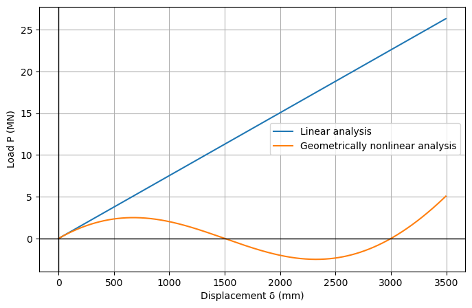

```python
plot_response(delta, P_lin, P_geo)
```

### Interpreting the Response Curve

From the plot, we observe:

- the **linear** solution increases indefinitely with constant slope
- the **geometrically nonlinear** solution gradually softens as displacement increases
- the two predictions agree at small displacement, then diverge more and more as deformation grows

This means the linear approximation becomes progressively less accurate as the geometry change becomes significant.

### Critical Point and Tangent Stiffness

The slope of the nonlinear response curve is the **tangent stiffness**.

At its peak the tangent stiffness becomes zero:

$$ \frac{dP}{d\delta} = 0 $$

When it reaches 0, the structure has reached a **critical** or **limit point**.

[figure not shown]

For the shallow two-member truss, the corresponding critical displacement is

$$ \delta_{cr} = L\left[\sin\theta - \cos\theta\sqrt{\frac{1}{(\cos\theta)^{2/3}} - 1}\right] \tag{14} $$

Substituting $\delta_{cr}$ into Eq. (13) gives the critical load $P_{cr}$.

This is the point where the structure loses its ability to resist any further increase in load along the same equilibrium path.

```python
delta_cr = L * (np.sin(theta) - np.cos(theta) * np.sqrt(1 / (np.cos(theta)**(2/3)) - 1))

x_cr = delta_cr / L
root_cr = np.sqrt(1 + x_cr**2 - 2 * x_cr * np.sin(theta))
P_cr = 2 * E * A * (np.sin(theta) - x_cr) * (1 - root_cr) / root_cr

print(f"Critical displacement δ_cr = {delta_cr:.2f} mm")
print(f"Critical load P_cr = {P_cr / 1e6:.3f} MN")
```

```
Critical displacement δ_cr = 675.78 mm
Critical load P_cr = 2.498 MN
```

### Physical Meaning of the Critical Point

The critical point marks the end of stable load increase along the original equilibrium branch.

Before that point:

- additional displacement requires additional load
- the structure still has positive tangent stiffness

At the critical point:

- the tangent stiffness becomes zero
- the response curve reaches a peak
- the structure is on the verge of instability

### Snap-Through Instability

Beyond the critical point, the truss cannot continue to carry additional load along the same equilibrium path.

Instead, it may undergo **snap-through**, in which a small change in loading triggers a sudden jump to a very different configuration.

[figure not shown]

### Why Snap-Through Matters

This behavior is important because:

- **large changes in shape** can occur suddenly
- the structure can lose stiffness before any material failure occurs
- the **linear model gives no warning** that this instability is approaching

The two-member truss, often called the **von Mises truss**, is also important historically and computationally.

Because its behavior is simple enough to study carefully, but rich enough to show true geometric instability, it is commonly used as a **benchmark problem** for validating geometrically nonlinear analysis programs.

### Why This Example Matters

This example captures the central idea of **geometric nonlinearity**:

- the material may remain **linearly elastic**
- but the **structural response** can still become strongly nonlinear
- the source of that nonlinearity is the **changing geometry** of the structure

That is exactly why geometric nonlinear analysis matters for:

- flexible structures with large deformations
- stability problems
- equilibrium shape finding
- later form-finding methods such as **force density** and **dynamic relaxation**

## Wrap-Up

In this lecture, we:

- introduced the basic idea of **structural nonlinearity**
- distinguished between **material** and **geometric** nonlinearity
- reviewed the main **levels of analysis**
- defined the course focus on **geometrically nonlinear axial-member structures**
- used a simple two-member truss to show how **changing geometry** leads to a nonlinear load-displacement response
- introduced the ideas of **critical point** and **snap-through instability**

Next: we will begin developing the member-level equations for **geometrically nonlinear plane truss analysis** and implement a basic **Newton-Raphson nonlinear solver**.